# ACE Reader

Download the `full notebook`.

# ACE Module

This notebook demonstrates basic usage of the `pyne.ace` module.

```python
import os
import matplotlib.pyplot as plt
import pyne.ace
if not os.path.isfile("W180.ace"):
    from urllib import urlretrieve
    urlretrieve("https://www-nds.iaea.org/wolfram/w180/beta3/W180.ace", "W180.ace")
```

```python
lib = pyne.ace.Library('W180.ace')
```

One can choose to read all tables in the file or selectively read a subset by specifying an argument to the `read` method.

```python
lib.read('74180.21c')
```

After the call to `read()`, the Library instance will have a dictionary called `tables`.

```python
lib.tables
```

```
{'74180.21c': <ACE Continuous-E Neutron Table: 74180.21c>}
```

```python
w180 = lib.tables['74180.21c']
```

Once a table is selected, we can inspect, e.g., the energy grid and the total cross section.

```python
w180.energy
```

```
array([  1.00000000e-11,   1.03125000e-11,   1.06250000e-11, ...,
         5.00000000e+01,   5.50000000e+01,   6.00000000e+01])
```

```python
w180.sigma_t
```

```
array([ 1544.50481   ,  1520.95229   ,  1498.44763   , ...,     4.17220824,
           4.26476628,     4.3440783 ])
```

To get data on a reaction, such as fission or $(n,2n)$, there is an attribute called `reactions`.

```python
w180.reactions
```

[output not shown]

```python
elastic = w180.reactions[2]
```

An instance of a Reaction contains the reaction cross section and any angular or energy distributions that may be present.

```python
elastic.sigma
```

```
array([ 43.83981,  43.20029,  42.58963, ...,   1.9508 ,   2.0991 ,   2.2343 ])
```

With the energy grid (stored on the table), and the cross section (stored on the reaction), one can generate plots of the cross section.

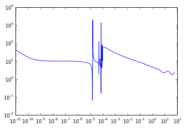

```python
plt.loglog(w180.energy, elastic.sigma)
```